# Sparkify Project Workspace

This workspace contains a tiny subset (128MB) of the full dataset available (12GB). Feel free to use this workspace to build your project, or to explore a smaller subset with Spark before deploying your cluster on the cloud. Instructions for setting up your Spark cluster is included in the last lesson of the Extracurricular Spark Course content.

You can follow the steps below to guide your data analysis and model building portion of this project.

```python
# import libraries
import datetime
import pandas as pd
import seaborn as sns
import matplotlib.pyplot as plt

from pyspark import SparkConf
from pyspark.sql import SparkSession, Window
from pyspark.sql.functions import sum as Fsum
from pyspark.sql.functions import min as fmin
from pyspark.sql.functions import max as fmax
from pyspark.sql.types import IntegerType, DoubleType
from pyspark.sql.functions import isnan, isnull, when, count, col, udf, avg, stddev, split

from pyspark.ml import Pipeline
from pyspark.ml.tuning import CrossValidator, ParamGridBuilder
from pyspark.ml.evaluation import MulticlassClassificationEvaluator
from pyspark.ml.feature import StringIndexer, OneHotEncoderEstimator, MinMaxScaler, VectorAssembler
from pyspark.ml.classification import LogisticRegression, DecisionTreeClassifier, RandomForestClassifier, LinearSVC

%matplotlib inline
```

```python
# create a Spark session
spark = SparkSession \
    .builder \
    .appName("Sparkify") \
    .getOrCreate()

spark.conf.set("spark.sql.shuffle.partitions", 4)
```

# Load and Clean Dataset

In this workspace, the mini-dataset file is `mini_sparkify_event_data.json`. Load and clean the dataset, checking for invalid or missing data - for example, records without userids or sessionids.

```python
file_name = "mini_sparkify_event_data.json"
user_log = spark.read.json(file_name)
```

```python
user_log.head()
```

```
Row(artist='Martha Tilston', auth='Logged In', firstName='Colin', gender='M', itemInSession=50, lastName='Freeman', length=277.89016, level='paid', location='Bakersfield, CA', method='PUT', page='NextSong', registration=1538173362000, sessionId=29, song='Rockpools', status=200, ts=1538352117000, use…
```

```python
user_log.printSchema()
```

```
root
 |-- artist: string (nullable = true)
 |-- auth: string (nullable = true)
 |-- firstName: string (nullable = true)
 |-- gender: string (nullable = true)
 |-- itemInSession: long (nullable = true)
 |-- lastName: string (nullable = true)
 |-- length: double (nullable = true)
 |-- level: string (nullable = true)
 |-- location: string (nullable = true)
 |-- method: string (nullable = true)
 |-- page: string (nullable = true)
 |-- registration: long (nullable = true)
 |-- sessionId: long (nullable = true)
 |-- song: string (nullable = true)
 |-- status: long (nullable = true)
 |-- ts: long (nullable = true)
 |-- userAgent: string (nullable = true)
 |-- userId: string (nullable = true)
```

```python
user_log.select([count(when(isnan(c), c)).alias(c) for c in user_log.columns]).show()
```

```
+------+----+---------+------+-------------+--------+------+-----+--------+------+----+------------+---------+----+------+---+---------+------+
|artist|auth|firstName|gender|itemInSession|lastName|length|level|location|method|page|registration|sessionId|song|status| ts|userAgent|userId|
+------+----+---------+------+-------------+--------+------+-----+--------+------+----+------------+---------+----+------+---+---------+------+
|     0|   0|        0|     0|            0|       0|     0|    0|       0|     0|   0|           0|        0|   0|     0|  0|        0|     0|
+------+----+---------+------+-------------+--------+------+-----+--------+------+----+------------+---------+----+------+---+---------+------+
```

```python
user_log.select([count(when(isnull(c), c)).alias(c) for c in user_log.columns]).show()
```

```
+------+----+---------+------+-------------+--------+------+-----+--------+------+----+------------+---------+-----+------+---+---------+------+
|artist|auth|firstName|gender|itemInSession|lastName|length|level|location|method|page|registration|sessionId| song|status| ts|userAgent|userId|
+------+----+---------+------+-------------+--------+------+-----+--------+------+----+------------+---------+-----+------+---+---------+------+
| 58392|   0|     8346|  8346|            0|    8346| 58392|    0|    8346|     0|   0|        8346|        0|58392|     0|  0|     8346|     0|
+------+----+---------+------+-------------+--------+------+-----+--------+------+----+------------+---------+-----+------+---+---------+------+
```

```python
user_log.select([count(when(col(c)=='', c)).alias(c) for c in user_log.columns]).show()
```

```
+------+----+---------+------+-------------+--------+------+-----+--------+------+----+------------+---------+----+------+---+---------+------+
|artist|auth|firstName|gender|itemInSession|lastName|length|level|location|method|page|registration|sessionId|song|status| ts|userAgent|userId|
+------+----+---------+------+-------------+--------+------+-----+--------+------+----+------------+---------+----+------+---+---------+------+
|     0|   0|        0|     0|            0|       0|     0|    0|       0|     0|   0|           0|        0|   0|     0|  0|        0|  8346|
+------+----+---------+------+-------------+--------+------+-----+--------+------+----+------------+---------+----+------+---+---------+------+
```

```python
# Drop rows with unregistered users
user_log = user_log.filter(user_log.userId != "")
```

```python
# Convert timestamps to date
date_conversion = udf(lambda x: datetime.datetime.fromtimestamp(x/1000.0).strftime("%Y-%m-%d %H:%M:%S"))
user_log = user_log.withColumn("date", date_conversion(user_log.ts))
user_log.head()
```

```
Row(artist='Martha Tilston', auth='Logged In', firstName='Colin', gender='M', itemInSession=50, lastName='Freeman', length=277.89016, level='paid', location='Bakersfield, CA', method='PUT', page='NextSong', registration=1538173362000, sessionId=29, song='Rockpools', status=200, ts=1538352117000, use…
```

# Exploratory Data Analysis

When you're working with the full dataset, perform EDA by loading a small subset of the data and doing basic manipulations within Spark. In this workspace, you are already provided a small subset of data you can explore.

### Exploring auth field

```python
user_log.select("auth").dropDuplicates().show()
```

```
+---------+
|     auth|
+---------+
|Logged In|
|Cancelled|
+---------+
```

```python
user_log.select("userId", "auth").dropDuplicates().groupby("auth").count().show()
```

```
+---------+-----+
|     auth|count|
+---------+-----+
|Logged In|  225|
|Cancelled|   52|
+---------+-----+
```

### Exploring gender field

```python
gender_count = user_log.select("userId", "gender") \
                        .dropDuplicates() \
                        .groupby("gender")\
                        .count() \
                        .withColumnRenamed("count", "user_counts")
gender_count.show()
```

```
+------+-----------+
|gender|user_counts|
+------+-----------+
|     F|        104|
|     M|        121|
+------+-----------+
```

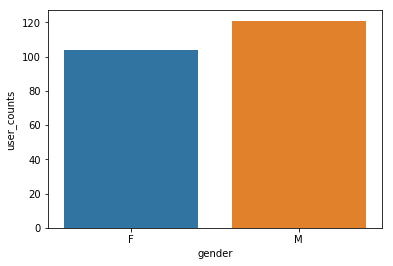

```python
sns.barplot(x='gender',y='user_counts',data=gender_count.toPandas());
```

### Exploring other fields

#### itemInSession

```python
user_log.select("itemInSession").dropDuplicates().count()
```

```
1311
```

#### length

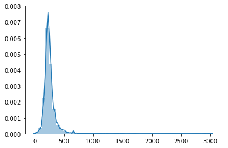

```python
length_data = user_log.select("length")
sns.distplot(length_data.toPandas().dropna());
```

Most of the length are in between 0 to 500

#### level

```python
user_log.select("userId", "level").dropDuplicates().groupby("level").count().withColumnRenamed("count", "user_counts").show()
```

```
+-----+-----------+
|level|user_counts|
+-----+-----------+
| free|        195|
| paid|        165|
+-----+-----------+
```

There were total 225 users, out of which 165 are paid ones, therefore 60 users are currently free users. This means that 135 users have changed their account level.

#### location

```python
location_count = user_log.select("userId", "location").dropDuplicates() \
                        .groupby("location").count() \
                        .withColumnRenamed("count", "user_counts") \
                        .sort("user_counts", ascending=False) \
                        .toPandas()
```

```python
location_count = location_count.join(location_count['location'].str.split(',',expand=True) \
                                .rename(columns={0:'city',1:'state'})).drop('location',axis=1)
```

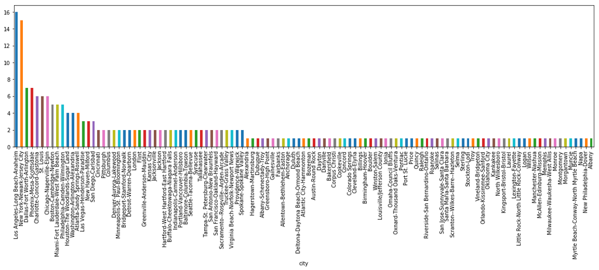

```python
location_count.groupby('city')['user_counts'].sum().sort_values(ascending=False).plot(kind='bar',figsize=(20,5));
```

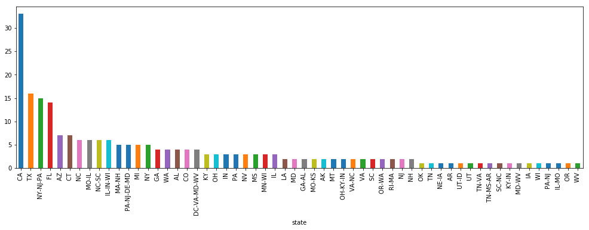

```python
location_count.groupby('state')['user_counts'].sum().sort_values(ascending=False).plot(kind='bar',figsize=(17,5));
```

Los Angeles and New York are top cities where large user base had while CA is the top state where large user base had.

#### page

```python
user_log.select("userId", "page").groupby("page").count() \
        .withColumnRenamed("count", "user_counts") \
        .sort("user_counts", ascending=False).show()
```

```
+--------------------+-----------+
|                page|user_counts|
+--------------------+-----------+
|            NextSong|     228108|
|           Thumbs Up|      12551|
|                Home|      10082|
|     Add to Playlist|       6526|
|          Add Friend|       4277|
|         Roll Advert|       3933|
|              Logout|       3226|
|         Thumbs Down|       2546|
|           Downgrade|       2055|
|            Settings|       1514|
|                Help|       1454|
|             Upgrade|        499|
|               About|        495|
|       Save Settings|        310|
|               Error|        252|
|      Submit Upgrade|        159|
|    Submit Downgrade|         63|
|              Cancel|         52|
|Cancellation Conf...|         52|
+--------------------+-----------+
```

#### date

```python
time_data = user_log.select("userId", "date").toPandas()

time_data["date"] = pd.to_datetime(time_data["date"])

weekday_dict = {0:"Mon.", 1:"Tues.", 2:"Wed.", 3:"Thur.", 4:"Fri.", 5:"Sat.", 6:"Sun."}
time_data["weekDay"] = time_data["date"].dt.weekday.map(weekday_dict)
time_data["day"] = time_data["date"].dt.day
time_data["hour"] = time_data["date"].dt.hour
```

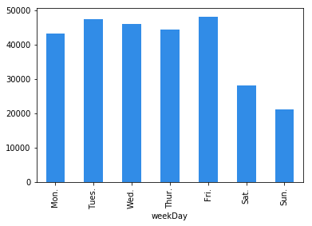

```python
time_data.groupby("weekDay")["userId"].count().loc[list(weekday_dict.values())].plot(kind="bar", color='#318ce7');
```

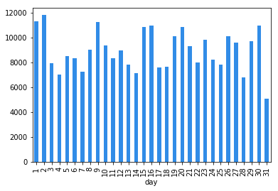

```python
time_data.groupby("day")["userId"].count().plot(kind="bar", color="#318ce7");
```

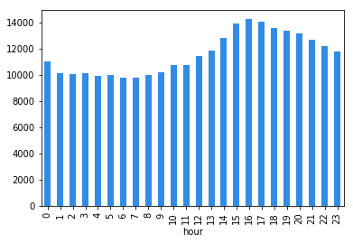

```python
time_data.groupby("hour")["userId"].count().plot(kind="bar", color="#318ce7");
```

Users uses Sparkify more often in workdays than weekends. In a single day, most users uses Sparkify after 13 O'clock.

### Define Churn

Once you've done some preliminary analysis, create a column `Churn` to use as the label for your model. I suggest using the `Cancellation Confirmation` events to define your churn, which happen for both paid and free users. As a bonus task, you can also look into the `Downgrade` events.

### Explore Data

Once you've defined churn, perform some exploratory data analysis to observe the behavior for users who stayed vs users who churned. You can start by exploring aggregates on these two groups of users, observing how much of a specific action they experienced per a certain time unit or number of songs played.

```python
# Identify users who canceled their registration
flag_cancel = udf(lambda x: 1 if x == 'Cancellation Confirmation' else 0, IntegerType())
user_log = user_log.withColumn('cancelPage', flag_cancel('page'))

windowval = Window.partitionBy('userId')
user_log = user_log.withColumn('Churn', Fsum('cancelPage').over(windowval))
```

```python
print('Number of users who have churned {}'.\
      format(user_log.filter(user_log.Churn == 1).select('userId').dropDuplicates().count()))
print('Number of users who have not churned {}'.\
      format(user_log.filter(user_log.Churn == 0).select('userId').dropDuplicates().count()))
```

```
Number of users who have churned 52
Number of users who have not churned 173
```

```python
user_log.head()
```

```
Row(artist=None, auth='Logged In', firstName='Gracie', gender='F', itemInSession=0, lastName='Chang', length=None, level='paid', location='Santa Maria-Santa Barbara, CA', method='GET', page='Home', registration=1529934689000, sessionId=38, song=None, status=200, ts=1539039445000, userAgent='Mozilla/…
```

### Explore data between two groups i.e. churned and not churned users

#### auth

```python
user_log.dropDuplicates(["userId"]).groupby(["Churn", "auth"]).count().sort("Churn").show()
```

```
+-----+---------+-----+
|Churn|     auth|count|
+-----+---------+-----+
|    0|Logged In|  173|
|    1|Logged In|   52|
+-----+---------+-----+
```

#### gender

```python
user_log.dropDuplicates(["userId", "gender"]).groupby(["Churn", "gender"]).count().sort("Churn").show()
```

```
+-----+------+-----+
|Churn|gender|count|
+-----+------+-----+
|    0|     M|   89|
|    0|     F|   84|
|    1|     F|   20|
|    1|     M|   32|
+-----+------+-----+
```

In males, churn rate is 0.264 while 0.192 in females.

#### length

```python
user_log.select(["Churn", "length"]) \
        .groupby(["Churn"]) \
        .agg(avg("length").alias('mean_length'),
            stddev("length").alias("stddev_length"),
            fmax("length").alias("max_length"),
            fmin("length").alias("min_length")).show()
```

```
+-----+------------------+-----------------+----------+----------+
|Churn|       mean_length|    stddev_length|max_length|min_length|
+-----+------------------+-----------------+----------+----------+
|    0| 249.2091353888082|98.62588300146898|3024.66567|   0.78322|
|    1|248.63279564406145|102.3849771757548|3024.66567|   4.04853|
+-----+------------------+-----------------+----------+----------+
```

#### level

```python
user_log.dropDuplicates(["userId"]).groupby(["Churn", "level"]).count().sort("Churn").show()
```

```
+-----+-----+-----+
|Churn|level|count|
+-----+-----+-----+
|    0| paid|   40|
|    0| free|  133|
|    1| paid|    8|
|    1| free|   44|
+-----+-----+-----+
```

#### location

```python
def normalize_data(groupby_data):
    groupby_series = groupby_data.set_index(list(groupby_data.columns[:2]))
    temp = groupby_series.unstack("Churn").fillna(0)
    df = pd.DataFrame(((temp - temp.min()) / (temp.max() - temp.min())).stack()).reset_index()
    df = df.rename(columns={df.columns[-1]: "result"})
    return df
```

```python
split_city_state = split(user_log['location'], ', ')
user_log = user_log.withColumn('city',split_city_state.getItem(0))
user_log = user_log.withColumn('state',split_city_state.getItem(1))
```

```python
city_data = user_log.dropDuplicates(["userId"]).groupby(["city","Churn"]).count().sort("city").toPandas()
city_data = normalize_data(city_data)
```

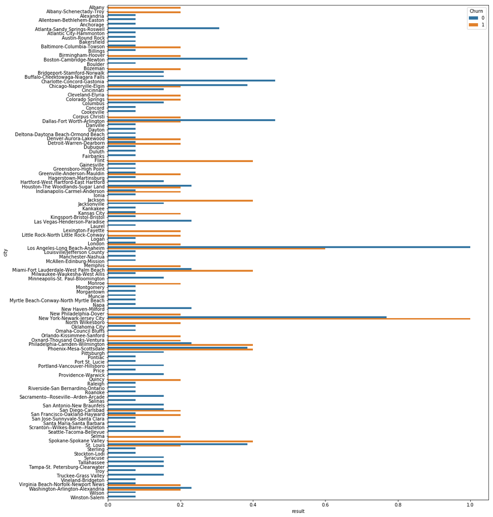

```python
fig, ax = plt.subplots(figsize=(15, 20))
sns.barplot( x="result",y="city", hue="Churn", data=city_data, ax=ax);
```

```python
state_data = user_log.dropDuplicates(["userId"]).groupby(["state","Churn"]).count().sort("state").toPandas()
state_data = normalize_data(state_data)
```

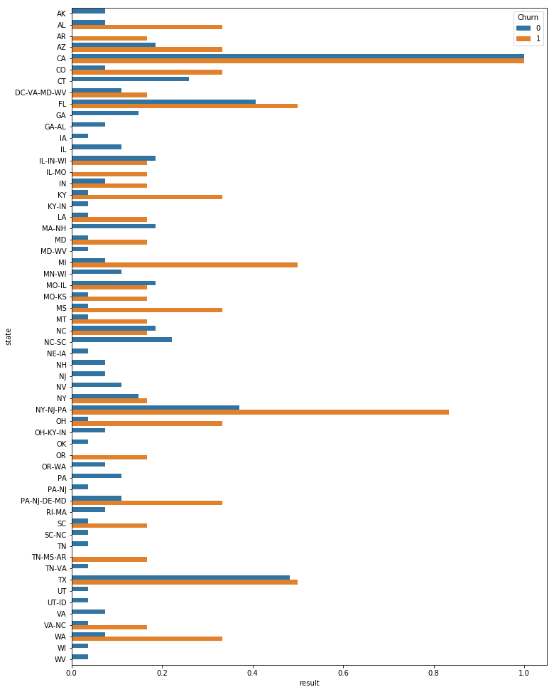

```python
fig, ax = plt.subplots(figsize=(12, 17))
sns.barplot( x="result",y="state", hue="Churn", data=state_data,ax=ax);
```

#### page

```python
user_log.select(["Churn", "page"]).groupby(["Churn", "page"]).count().sort("page").show()
```

```
+-----+--------------------+------+
|Churn|                page| count|
+-----+--------------------+------+
|    0|               About|   439|
|    1|               About|    56|
|    0|          Add Friend|  3641|
|    1|          Add Friend|   636|
|    1|     Add to Playlist|  1038|
|    0|     Add to Playlist|  5488|
|    1|              Cancel|    52|
|    1|Cancellation Conf...|    52|
|    0|           Downgrade|  1718|
|    1|           Downgrade|   337|
|    1|               Error|    32|
|    0|               Error|   220|
|    0|                Help|  1215|
|    1|                Help|   239|
|    0|                Home|  8410|
|    1|                Home|  1672|
|    1|              Logout|   553|
|    0|              Logout|  2673|
|    0|            NextSong|191714|
|    1|            NextSong| 36394|
+-----+--------------------+------+
only showing top 20 rows
```

```python
page_data = user_log.select(["page","Churn"]).groupby([ "page","Churn"]).count().sort("page").toPandas()
page_data = normalize_data(page_data)
```

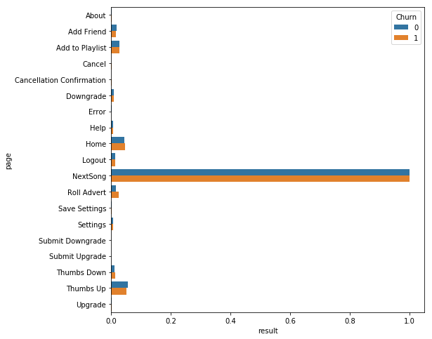

```python
fig, ax = plt.subplots(figsize=(8,8))
sns.barplot( x="result",y="page", hue="Churn", data=page_data,ax=ax);
```

#### time

```python
get_hour = udf(lambda x: datetime.datetime.fromtimestamp(x / 1000.0).hour)
get_day = udf(lambda x: datetime.datetime.fromtimestamp(x / 1000.0).day)
get_weekday = udf(lambda x: datetime.datetime.fromtimestamp(x / 1000.0).strftime("%w"))
```

```python
user_log = user_log.withColumn("hour", get_hour(user_log.ts))
user_log = user_log.withColumn("day", get_day(user_log.ts))
user_log = user_log.withColumn("dayofweek", get_weekday(user_log.ts))
```

```python
hour_data = user_log.select(["Churn", "hour"]).groupby(["Churn", "hour"]).count().sort("hour").toPandas()
day_data = user_log.select(["Churn", "day"]).groupby(["Churn", "day"]).count().sort("day").toPandas()
dayofweek_data = user_log.select(["Churn", "dayofweek"]).groupby(["Churn", "dayofweek"]).count() \
                        .sort("dayofweek").toPandas()
```

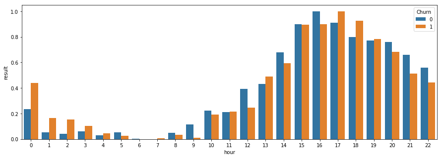

```python
hour_data = normalize_data(hour_data)

fig, ax = plt.subplots(figsize=(15,5))
sns.barplot( x="hour",y="result", hue="Churn", data=hour_data,ax=ax,order=list(map(lambda x: str(x),range(23))));
```

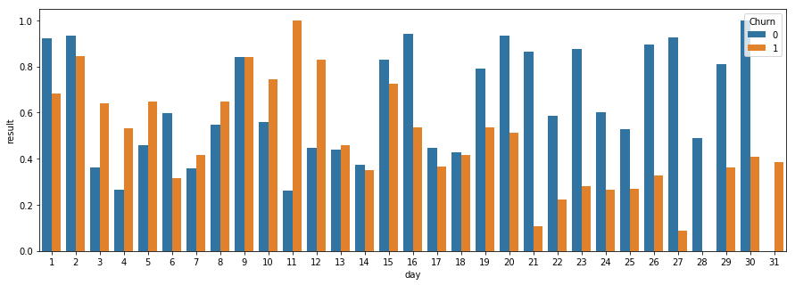

```python
day_data = normalize_data(day_data)

fig, ax = plt.subplots(figsize=(15,5))
sns.barplot( x="day",y="result", hue="Churn", data=day_data,ax=ax,order=list(map(lambda x: str(x),range(1,32))));
```

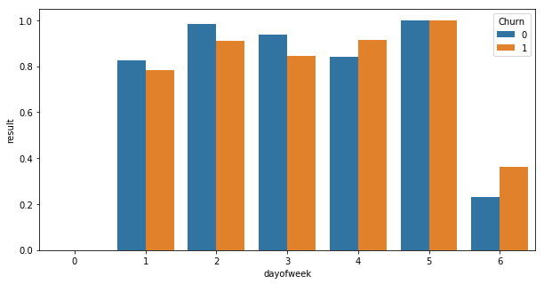

```python
dayofweek_data = normalize_data(dayofweek_data)

fig, ax = plt.subplots(figsize=(10,5))
sns.barplot( x="dayofweek",y="result", hue="Churn", data=dayofweek_data,ax=ax);
```

# Feature Engineering

Once you've familiarized yourself with the data, build out the features you find promising to train your model on. To work with the full dataset, you can follow the following steps.

- Write a script to extract the necessary features from the smaller subset of data
- Ensure that your script is scalable, using the best practices discussed in Lesson 3
- Try your script on the full data set, debugging your script if necessary

If you are working in the classroom workspace, you can just extract features based on the small subset of data contained here. Be sure to transfer over this work to the larger dataset when you work on your Spark cluster.

```python
user_log.printSchema()
```

```
root
 |-- artist: string (nullable = true)
 |-- auth: string (nullable = true)
 |-- firstName: string (nullable = true)
 |-- gender: string (nullable = true)
 |-- itemInSession: long (nullable = true)
 |-- lastName: string (nullable = true)
 |-- length: double (nullable = true)
 |-- level: string (nullable = true)
 |-- location: string (nullable = true)
 |-- method: string (nullable = true)
 |-- page: string (nullable = true)
 |-- registration: long (nullable = true)
 |-- sessionId: long (nullable = true)
 |-- song: string (nullable = true)
 |-- status: long (nullable = true)
 |-- ts: long (nullable = true)
 |-- userAgent: string (nullable = true)
 |-- userId: string (nullable = true)
 |-- date: string (nullable = true)
 |-- cancelPage: integer (nullable = true)
 |-- Churn: long (nullable = true)
 |-- city: string (nullable = true)
 |-- state: string (nullable = true)
 |-- hour: string (nullable = true)
 |-- day: string (nullable = true)
 |-- dayofweek: string (nullable = true)
```

On the basis of above EDA, we will select following features.

- Categorical features
- gender
- level
- state
- Numerical features
- mean, max, min, std of length of users
- number of unique songs and total songs of users
- number of unique artists of users

#### Categorical features

```python
stages = []

for categoricalCol in ["gender", "level", "state"]:

    si = StringIndexer(inputCol = categoricalCol, outputCol = categoricalCol+"_code", stringOrderType = "alphabetDesc")
    ohe = OneHotEncoderEstimator(inputCols = [si.getOutputCol()], outputCols=[categoricalCol + "ClassVec"])

    stages.extend([si, ohe])
```

#### Numerical features

```python
# length
feature_length = user_log.select(["userId", "length"]) \
                        .groupby(["userId"]) \
                        .agg(avg("length").alias("mean_length"),
                            stddev("length").alias("stdev_length"),
                            fmax("length").alias("max_length"),
                            fmin("length").alias("min_length"))

# Unique songs
feature_nunique_song = user_log.filter(user_log.page=="NextSong").select(["userId","song"]) \
                                .dropDuplicates(["userId","song"]).groupby(["userId"]).count()
feature_nunique_song = feature_nunique_song.selectExpr("userId as userId","count as nunique_song")

# Total songs
feature_ntotal_song = user_log.filter(user_log.page=="NextSong").select(["userId","song"]) \
                                .groupby(["userId"]).count()
feature_ntotal_song = feature_ntotal_song.selectExpr("userId as userId","count as ntotal_song")

# Unique artists
feature_nunique_artist = user_log.filter(user_log.page=="NextSong").select(["userId","artist"]) \
                                .dropDuplicates(["userId","artist"]).groupby(["userId"]).count()
feature_nunique_artist = feature_nunique_artist.selectExpr("userId as userId","count as nunique_artist")

#merge together
user_log = user_log.join(feature_length, on="userId", how="inner") \
                    .join(feature_nunique_song,on="userId",how="inner") \
                    .join(feature_ntotal_song,on="userId",how="inner") \
                    .join(feature_nunique_artist,on="userId",how="inner")
```

```python
feature_data = user_log.select(["userId", "Churn", "gender", "level", "state", "mean_length", "stdev_length", "max_length",
                                "min_length", "nunique_song", "ntotal_song", "nunique_artist"]).dropDuplicates()
feature_data.head(2)
```

```
[Row(userId='100002', Churn=0, gender='F', level='paid', state='CA', mean_length=254.15342615384608, stdev_length=91.06822781427947, max_length=732.39465, min_length=68.67546, nunique_song=193, ntotal_song=195, nunique_artist=184),
 Row(userId='100010', Churn=0, gender='F', level='free', state='CT', mean_length=243.421444909091, stdev_length=79.5156544698794, max_length=538.85342, min_length=52.27057, nunique_song=269, ntotal_song=275, nunique_artist=252)]
```

```python
numerical_cols = ["mean_length", "stdev_length", "max_length", "min_length", "nunique_song", "ntotal_song", "nunique_artist"]

assembler_numerical = VectorAssembler(inputCols = numerical_cols, outputCol = "num_features")
stages.append(assembler_numerical)

minmax_scale = MinMaxScaler(inputCol = "num_features", outputCol= "numFeaturesScaled")
stages.append(minmax_scale)
```

```python
feature_cols = ["numFeaturesScaled", "genderClassVec", "levelClassVec", "stateClassVec"]
assembler = VectorAssembler(inputCols = feature_cols, outputCol = "features")
stages.append(assembler)

label_indexer = StringIndexer(inputCol = "Churn", outputCol = "label")
stages.append(label_indexer)
```

```python
# Convert the stages contained in list into a pipeline
pipeline = Pipeline().setStages(stages)
data_prep_model = pipeline.fit(feature_data)
final_data = data_prep_model.transform(feature_data)
```

# Modeling

Split the full dataset into train, test, and validation sets. Test out several of the machine learning methods you learned. Evaluate the accuracy of the various models, tuning parameters as necessary. Determine your winning model based on test accuracy and report results on the validation set. Since the churned users are a fairly small subset, I suggest using F1 score as the metric to optimize.

```python
# Perform Tain-Test Split
train, test = final_data.randomSplit([0.8, 0.2], seed = 42)
```

```python
# Initialize different algorithms
clf_lr = LogisticRegression()
lr_model = clf_lr.fit(train)

clf_dt = DecisionTreeClassifier(seed=42)
dt_model = clf_dt.fit(train)

clf_rf = RandomForestClassifier(seed=42)
rf_model = clf_rf.fit(train)

clf_svc = LinearSVC()
svc_model = clf_svc.fit(train)

# Create lists with models and model names
model_list = [lr_model, dt_model, rf_model, svc_model]
model_names = ["logistic regression", "decision tree", "random forest", "linear svc"]
```

```python
for i in range(len(model_list)):
    model = model_list[i]
    model_name = model_names[i]
    predict = model.transform(test)

    # Instantiate evaluator
    evaluator = MulticlassClassificationEvaluator()

    print("F1 Score for "+model_names[i]+" :{0:.4f}".format(evaluator.evaluate(predict, {evaluator.metricName:"f1"})))
```

```
F1 Score for logistic regression :0.7101
F1 Score for decision tree :0.6528
F1 Score for random forest :0.6205
F1 Score for linear svc :0.6614
```

As Logistic Regression has highest f1 score, so we'll choose to further tune it.

#### Hyperparameter tuning

```python
paramGrid = ParamGridBuilder() \
            .addGrid(clf_lr.elasticNetParam, [0.1, 0.5, 1]) \
            .addGrid(clf_lr.regParam, [0.01, 0.05, 0.1]) \
            .addGrid(clf_lr.maxIter, [50, 100, 200]) \
            .build()

crossval = CrossValidator(estimator=clf_lr,
                          estimatorParamMaps=paramGrid,
                          evaluator=MulticlassClassificationEvaluator(metricName="f1"),
                          numFolds=3)

cvModel_lr = crossval.fit(train)
```

```python
predict = cvModel_lr.transform(test)

print('Accuracy: {}'.format(evaluator.evaluate(predict, {evaluator.metricName: "accuracy"})))
print('F-1 Score:{}'.format(evaluator.evaluate(predict, {evaluator.metricName: "f1"})))
```

```
Accuracy: 0.7333333333333333
F-1 Score:0.6429924242424243
```

```python
cvModel_lr.save("lr_model")
```

The model perform slightly bad after applying cross-validation hyperparameter tuning. This is because we used a dataset with a small number of churned users which further shrinks when we apply cross validation.

# Final Steps

Clean up your code, adding comments and renaming variables to make the code easier to read and maintain. Refer to the Spark Project Overview page and Data Scientist Capstone Project Rubric to make sure you are including all components of the capstone project and meet all expectations. Remember, this includes thorough documentation in a README file in a Github repository, as well as a web app or blog post.